# PS10 pre-lecture: inference for regression

## Inference for regression

putting a confidence interval on a **slope**

is the slope real? `beta-1`

- `get_regression_table()`
- `specify()`
- `calculate(stat = "slope")`
- `get_ci()`

Old Faithful: waiting time against eruption duration

## The question

One Sample, One Slope

- The slope you fit is a **statistic**, not the truth.
- The population slope is a **parameter** you never see.
- So the slope has a sampling distribution, like any other estimate.
- This chapter puts an interval and a p-value on it.

## lm()

Example

the fitted model, saved for later

```r
faithful_model <- lm(waiting ~ duration, data = old_faithful_2024)
```

response ~ explanatory where those two variables live

## get_regression_table()

Example

```r
get_regression_table(faithful_model)
```

```
# A tibble: 2 × 7
  term      estimate std_error statistic p_value lower_ci upper_ci
  <chr>        <dbl>     <dbl>     <dbl>   <dbl>    <dbl>    <dbl>
1 intercept   79.5       7.31       10.9       0   65.0     93.9
2 duration     0.371     0.032      11.4       0    0.307    0.435
```

the verb (function) the fitted model

## Reading the row

What The Columns Mean

- **estimate** is the fitted slope or intercept.
- **std_error** is how much it would bounce between samples.
- **p_value** tests whether that coefficient could be zero.
- **lower_ci** and **upper_ci** bracket the plausible values.

## conditions

LINE

Linearity, Independence, Normality of residuals, Equal variance.

## Checking LINE

Residual Plots

- **Linearity**: the scatterplot should not curve.
- **Independence**: think about how the data were collected.
- **Normality**: a histogram or Q-Q plot of the residuals.
- **Equal variance**: residuals against fitted values, no funnel shape.

## get_regression_points()

Example

fitted values and residuals

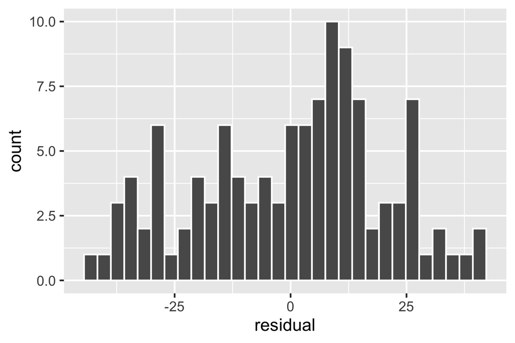

```r
faithful_points <- get_regression_points(faithful_model)
ggplot(faithful_points, aes(x = residual)) +
  geom_histogram(color = "white")
```

a histogram of the residuals

what to plot

## calculate()

Example

```r
bootstrap_distn_slope <- old_faithful_2024 |>
  specify(waiting ~ duration) |>
  generate(reps = 1000, type = "bootstrap") |>
  calculate(stat = "slope")
```

the slope, not a mean this time

response ~ explanatory

## observed slope

Example

```r
observed_slope <- old_faithful_2024 |>
  specify(waiting ~ duration) |>
  calculate(stat = "slope")
```

no resampling: this is your data

## get_ci()

Example

```r
bootstrap_distn_slope |>
  get_ci(level = 0.95, type = "se", point_estimate = observed_slope)
```

the verb (function) how confident the standard error method center it on the slope you observed

## Putting it together

Theory & Simulation

- **get_regression_table()** gives the theory-based interval and p-value.
- The **infer** pipeline gives the simulation-based version.
- When the conditions hold, the two agree closely.
- If the interval excludes zero, the slope is distinguishable from zero.